# Preliminary Results Summary 6-16-17

Cecina Babich Morrow

June 16, 2017

The following is an overview of what I have been working on.

## Loading packages and creating color defaults

```r
library(readr)
library(lattice)
library(RColorBrewer)
library(ggplot2)
library(tidyr)
library(hypervolume)
myColours <- brewer.pal(6,"Set2")
my.settings <- list(
  superpose.polygon=list(col=myColours[1:4], border="transparent"),
  strip.background=list(col=myColours[6]),
  strip.border=list(col="black")
)
gg_color_hue <- function(n) {
  hues = seq(15, 375, length = n + 1)
  hcl(h = hues, l = 65, c = 100)[1:n]
}
```

## Importing the data

Prior to importing the data, I replaced all of the -999 values with NA in the .csv file.

```r
Amniote_Database_Aug_2015 <- read_csv("C:/Users/Cecina/Desktop/Amniote_Database_Aug_2015.csv")
Amniote_Database_Aug_2015$weaning_weight_g<-as.numeric(Amniote_Database_Aug_2015$weaning_weight_g)
```

## Calculating Charnov’s invariants

### $C\cdot E$

The first invariant trait is $C\cdot E$, where $C$ is reproductive effort and $E$ is average adult lifespan. Thus $C\cdot E$ represents the fraction of body mass allocated to reproduction per death (Charnov 2002).

Charnov (2002) defines $C$ as $R/m$, where $R$ is the average reproductive allocation per unit time and $m$ is average adult mass.

#### $R$

Charnov defines $R$ as an organism’s average allocation to reproduction per unit time (Charnov 2002). To calculate this value, I first multiplied the litter or clutch size of the organism by the number of litters or clutches per year to determine the number of offspring in a year. Then, I multiplied this number by the mass of offspring at independence. The mass at independence was represented by fledging mass for birds, weaning weight for mammals, and hatching size for reptiles. I selected hatching size, rather than egg mass, for the reptiles because the database has better trait coverage for reptile hatching size.

```r
for (i in 1:nrow(Amniote_Database_Aug_2015)) {
  #print(i)
  if(Amniote_Database_Aug_2015$class[i]=='Mammalia') {
    Amniote_Database_Aug_2015[i, 'R'] <- Amniote_Database_Aug_2015[i,"litter_or_clutch_size_n"]*Amniote_Database_Aug_2015[i,"litters_or_clutches_per_y"]*Amniote_Database_Aug_2015[i,"weaning_weight_g"]
  }
  else if(Amniote_Database_Aug_2015$class[i]=='Reptilia') {
    Amniote_Database_Aug_2015[i, 'R'] <- Amniote_Database_Aug_2015[i,"litter_or_clutch_size_n"]*Amniote_Database_Aug_2015[i,"litters_or_clutches_per_y"]*Amniote_Database_Aug_2015[i,"birth_or_hatching_weight_g"]
  }
  else if(Amniote_Database_Aug_2015$class[i]=='Aves') {
    Amniote_Database_Aug_2015[i, 'R'] <- Amniote_Database_Aug_2015[i,"litter_or_clutch_size_n"]*Amniote_Database_Aug_2015[i,"litters_or_clutches_per_y"]*Amniote_Database_Aug_2015[i,"fledging_mass_g"]
  }
}
```

Thus $R$ is the amount of mass allocated by a parent to offspring every year.

```r
length(Amniote_Database_Aug_2015$R[!is.na(Amniote_Database_Aug_2015$R)])
```

```
[1] 1964
```

```r
length(Amniote_Database_Aug_2015$R[!is.na(Amniote_Database_Aug_2015$R) & Amniote_Database_Aug_2015$class=="Aves"])
```

```
[1] 197
```

```r
length(Amniote_Database_Aug_2015$R[!is.na(Amniote_Database_Aug_2015$R) & Amniote_Database_Aug_2015$class=="Mammalia"])
```

```
[1] 942
```

```r
length(Amniote_Database_Aug_2015$R[!is.na(Amniote_Database_Aug_2015$R) & Amniote_Database_Aug_2015$class=="Reptilia"])
```

```
[1] 825
```

There are 1964 species in the database with $R$ values: 197 birds, 942 mammals, and 825 reptiles.

#### $C$

Then I calculated $C=R/m$:

```r
Amniote_Database_Aug_2015$C<-Amniote_Database_Aug_2015$R/Amniote_Database_Aug_2015$adult_body_mass_g
```

```r
length(Amniote_Database_Aug_2015$C[!is.na(Amniote_Database_Aug_2015$C)])
```

```
[1] 1957
```

There are 1957 species with value for $C$.

Finally, I calculated $C\cdot E$:

```r
Amniote_Database_Aug_2015$C_E<-Amniote_Database_Aug_2015$C*Amniote_Database_Aug_2015$longevity_y
length(Amniote_Database_Aug_2015$C_E[!is.na(Amniote_Database_Aug_2015$C_E)])
```

```
[1] 1416
```

```r
length(Amniote_Database_Aug_2015$C_E[!is.na(Amniote_Database_Aug_2015$C_E) & Amniote_Database_Aug_2015$class=="Aves"])
```

```
[1] 185
```

```r
length(Amniote_Database_Aug_2015$C_E[!is.na(Amniote_Database_Aug_2015$C_E) & Amniote_Database_Aug_2015$class=="Mammalia"])
```

```
[1] 897
```

```r
length(Amniote_Database_Aug_2015$C_E[!is.na(Amniote_Database_Aug_2015$C_E) & Amniote_Database_Aug_2015$class=="Reptilia"])
```

```
[1] 334
```

There are 1416 species with values for $C\cdot E$: 185 birds, 897 mammals, and 334 reptiles.

### $E/ \alpha$

The second invariant trait is $E/ \alpha$, where $E$ is once again average lifespan and $\alpha$ is the time to female maturity. This ratio represents the trade-off between life-span and time to reproduction.

In order to keep the ratio dimensionless, I converted the longevity values from years to days.

```r
Amniote_Database_Aug_2015$E_alpha<-Amniote_Database_Aug_2015$longevity_y*365/Amniote_Database_Aug_2015$female_maturity_d
length(Amniote_Database_Aug_2015$E_alpha[!is.na(Amniote_Database_Aug_2015$E_alpha)])
```

```
[1] 3126
```

```r
length(Amniote_Database_Aug_2015$E_alpha[!is.na(Amniote_Database_Aug_2015$E_alpha) & Amniote_Database_Aug_2015$class=="Aves"])
```

```
[1] 1095
```

```r
length(Amniote_Database_Aug_2015$E_alpha[!is.na(Amniote_Database_Aug_2015$E_alpha) & Amniote_Database_Aug_2015$class=="Mammalia"])
```

```
[1] 1801
```

```r
length(Amniote_Database_Aug_2015$E_alpha[!is.na(Amniote_Database_Aug_2015$E_alpha) & Amniote_Database_Aug_2015$class=="Reptilia"])
```

```
[1] 230
```

There are 3126 species with values for $E/ \alpha$: 1095 birds, 1801 mammals, and 230 reptiles.

### $I / m$

The third invariant trait is $I / m$, where $I$ is the mass of an offspring at independence and $m$ is average adult body mass. This ratio describes the relative size of an independent offspring.

#### $I$

First I calculated $I$ according to the same definitions I used when calculating $R$: fledging mass for birds, weaning weight for mammals, and hatching mass for reptiles.

```r
for (i in 1:nrow(Amniote_Database_Aug_2015)) {
  #print(i)
  if(Amniote_Database_Aug_2015$class[i]=='Mammalia') {
    Amniote_Database_Aug_2015[i, 'I'] <- Amniote_Database_Aug_2015[i,"weaning_weight_g"]
  }
  else if(Amniote_Database_Aug_2015$class[i]=='Reptilia') {
    Amniote_Database_Aug_2015[i, 'I'] <- Amniote_Database_Aug_2015[i,"birth_or_hatching_weight_g"]
  }
  else if(Amniote_Database_Aug_2015$class[i]=='Aves') {
    Amniote_Database_Aug_2015[i, 'I'] <- Amniote_Database_Aug_2015[i,"fledging_mass_g"]
  }
}
```

Then I calculated $I/m$:

```r
Amniote_Database_Aug_2015$I_m<-Amniote_Database_Aug_2015$I/Amniote_Database_Aug_2015$adult_body_mass_g
#How many non-NA values for I/m?
length(Amniote_Database_Aug_2015$I_m[!is.na(Amniote_Database_Aug_2015$I_m)])
```

```
[1] 2127
```

```r
#How many birds?
length(Amniote_Database_Aug_2015$I_m[!is.na(Amniote_Database_Aug_2015$I_m) & Amniote_Database_Aug_2015$class=="Aves"])
```

```
[1] 211
```

```r
#How many mammals?
length(Amniote_Database_Aug_2015$I_m[!is.na(Amniote_Database_Aug_2015$I_m) & Amniote_Database_Aug_2015$class=="Mammalia"])
```

```
[1] 1061
```

```r
#How many reptiles?
length(Amniote_Database_Aug_2015$I_m[!is.na(Amniote_Database_Aug_2015$I_m) & Amniote_Database_Aug_2015$class=="Reptilia"])
```

```
[1] 855
```

There are 2127 species with values for $I/m$: 211 birds, 1061 mammals, and 855 reptiles.

## Trait Coverage

Next I determined how many species had values for all three of the invariant traits.

```r
#How many species have values for E/alpha, C*E, and I/m?
sum(complete.cases(Amniote_Database_Aug_2015[,c(39,40,42)]))
```

```
[1] 1138
```

```r
#How many birds?
length(Amniote_Database_Aug_2015$species[complete.cases(Amniote_Database_Aug_2015[,c(39,40,42)]) & Amniote_Database_Aug_2015$class=="Aves"])
```

```
[1] 172
```

```r
#How many mammals?
length(Amniote_Database_Aug_2015$species[complete.cases(Amniote_Database_Aug_2015[,c(39,40,42)]) & Amniote_Database_Aug_2015$class=="Mammalia"])
```

```
[1] 849
```

```r
#How many reptiles?
length(Amniote_Database_Aug_2015$species[complete.cases(Amniote_Database_Aug_2015[,c(39,40,42)]) & Amniote_Database_Aug_2015$class=="Reptilia"])
```

```
[1] 117
```

1138 species have complete cases for all three traits: 172 birds, 849 mammals, and 117 reptiles.

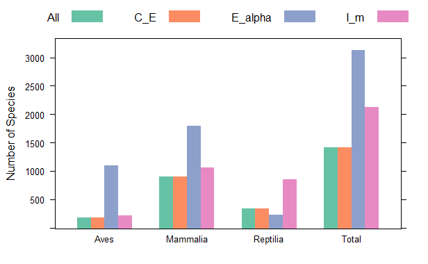

```r
require(tidyr)
traitcoverage<-data.frame(Class=c("Aves","Mammalia","Reptilia"),C_E=numeric(3),E_alpha=numeric(3),I_m=numeric(3),All=numeric(3))
for(i in 1:3){
  traitcoverage$C_E[i]<-length(Amniote_Database_Aug_2015$C_E[!is.na(Amniote_Database_Aug_2015$C_E) & Amniote_Database_Aug_2015$class==traitcoverage$Class[i]])
}
for(i in 1:3){
  traitcoverage$E_alpha[i]<-length(Amniote_Database_Aug_2015$E_alpha[!is.na(Amniote_Database_Aug_2015$E_alpha) & Amniote_Database_Aug_2015$class==traitcoverage$Class[i]])
}
for(i in 1:3){
  traitcoverage$I_m[i]<-length(Amniote_Database_Aug_2015$I_m[!is.na(Amniote_Database_Aug_2015$I_m) & Amniote_Database_Aug_2015$class==traitcoverage$Class[i]])
}
for(i in 1:3){
  traitcoverage$All[i]<-length(Amniote_Database_Aug_2015$species[complete.cases(Amniote_Database_Aug_2015[,c(39,41,42)]) & Amniote_Database_Aug_2015$class==traitcoverage$Class[i]])
}
traitcoverage$C_E<-as.numeric(traitcoverage$C_E)
traitcoverage$E_alpha<-as.numeric(traitcoverage$E_alpha)
traitcoverage$I_m<-as.numeric(traitcoverage$I_m)
traitcoverage$All<-as.numeric(traitcoverage$All)
traitcoverage$Class<-as.character(traitcoverage$Class)
#Add a row of totals
traitcoverage<-rbind(traitcoverage,c("Total",colSums(traitcoverage[,2:5])))
traitcoverage[4,1]<-"Total"
speciesperinvariant<-gather(traitcoverage,key = Class)
colnames(speciesperinvariant)<-c("Class","Trait","Count")
speciesperinvariant$Count<-as.numeric(speciesperinvariant$Count)
barchart(Count~Class,data=speciesperinvariant,groups=Trait,ylab="Number of Species",auto.key=list(space="top",columns=4),par.settings=my.settings)
```

Overall, we have the best trait coverage for mammals. $E/ \alpha$ is the trait with the most values for both birds and mammals (although not for reptiles). We have at least 100 species in every class with values for each of the traits.

## Trait Distributions

I created histograms of body mass and the three invariant traits to examine the distributions. Following the total distribution of all species, I plotted separate distributions for birds, mammals, and reptiles.

Body mass:

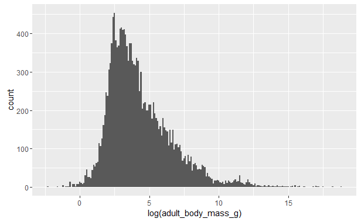

```r
ggplot(data=Amniote_Database_Aug_2015,aes(x=log(adult_body_mass_g)))+
  geom_histogram(binwidth = 0.1)
```

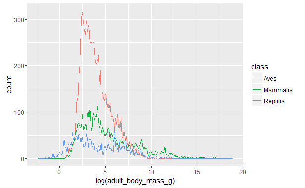

```r
ggplot(data=Amniote_Database_Aug_2015[!is.na(Amniote_Database_Aug_2015$adult_body_mass_g),],aes(x=log(adult_body_mass_g),colour=class))+
  geom_freqpoly(binwidth = 0.1)
```

The three classes have relatively similar centers for their body mass distributions, but they differ in spread and shape of the distribution. Mammals and reptiles have a wider range than the birds, and the reptile distribution is relatively flat in general.

For the three invariant traits, I included vertical dotted lines showing Charnov’s estimates for the trait values of mammals and altricial birds (Charnov 2002). These often aren’t very close to the values I’ve calculated, but they appear remarkably accurate for $I/m$.

$C\cdot E$:

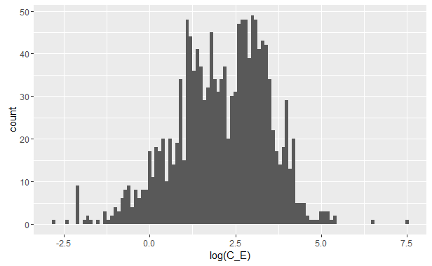

```r
ggplot(data=Amniote_Database_Aug_2015,aes(x=log(C_E)))+
  geom_histogram(binwidth = 0.1)
```

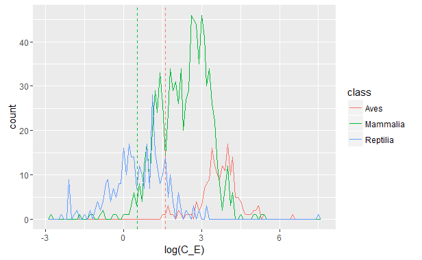

```r
ggplot(data=Amniote_Database_Aug_2015[!is.na(Amniote_Database_Aug_2015$C_E),],aes(x=log(C_E),colour=class))+
  geom_freqpoly(binwidth = 0.1)+
  geom_vline(aes(xintercept=log(5)),color=gg_color_hue(3)[1],lty=2)+
  geom_vline(aes(xintercept= log(1.7)),color=gg_color_hue(3)[2],lty=2)
```

The overall distribution of $C\cdot E$ values appears bimodal. This is driven by the offsets in the distributions of reptiles and mammals (and, to a lesser extent, birds). The three classes have very distinct centers. Reptiles have the lowest $C\cdot E$, followed by mammals, and then birds. Thus birds have the highest reproductive payoff per unit death cost. Mammals also have a relatively high payoff relative to death cost, but a wider range. Reptiles have the lowest payoff and a wide range of values.

$E/ \alpha$:

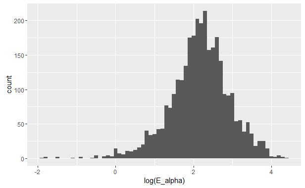

```r
ggplot(data=Amniote_Database_Aug_2015,aes(x=log(E_alpha)))+
  geom_histogram(binwidth = 0.1)
```

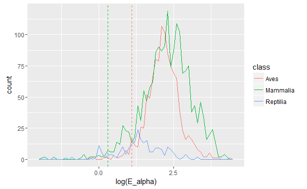

```r
ggplot(data=Amniote_Database_Aug_2015[!is.na(Amniote_Database_Aug_2015$E_alpha),],aes(x=log(E_alpha),colour=class))+
  geom_freqpoly(binwidth = 0.1)+
  geom_vline(aes(xintercept=log(3)),color=gg_color_hue(3)[1],lty=2)+
  geom_vline(aes(xintercept= log(1.35)),color=gg_color_hue(3)[2],lty=2)
```

The distributions of values for $E/ \alpha$ are more similar across the different classes. Mammals have a wider spread than birds, however, demonstrating more variation in the relationship between lifespan and time to reproduction. Reptiles have the lowest $E/ \alpha$ values, possibly driven by very high times to reproduction in long-lived reptiles.

$I/m$:

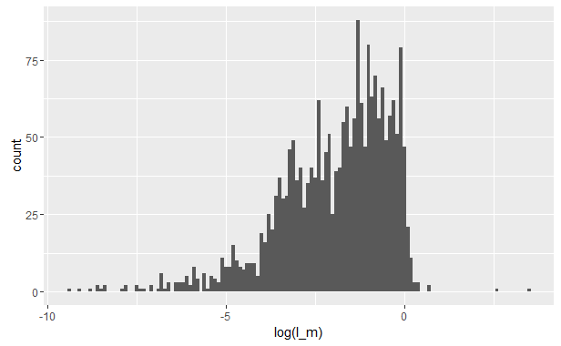

```r
ggplot(data=Amniote_Database_Aug_2015,aes(x=log(I_m)))+
  geom_histogram(binwidth = 0.1)
```

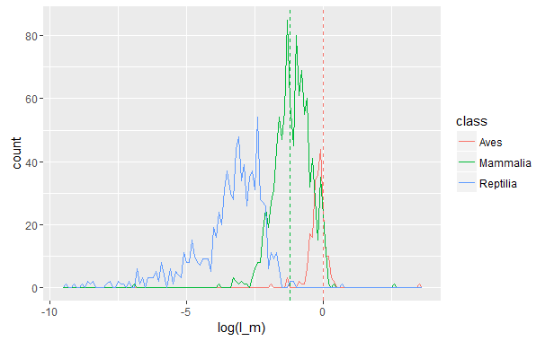

```r
ggplot(data=Amniote_Database_Aug_2015[!is.na(Amniote_Database_Aug_2015$I_m),],aes(x=log(I_m),colour=class))+
  geom_freqpoly(binwidth = 0.1)+
  geom_vline(aes(xintercept=log(1)),color=gg_color_hue(3)[1],lty=2)+
  geom_vline(aes(xintercept= log(0.3)),color=gg_color_hue(3)[2],lty=2)
```

The three classes had very distinct distributions for $I/m$. Reptiles have the lowest values, suggesting that their mass at independence is quite low relative to their adult mass. Since the vast majority of reptiles are independent immediately upon hatching, this result makes sense. Mammals had intermediate $I/m$ values remarkably similar to the value projected by Charnov (2002). Birds have high masses at independence relative to adult mass, also following Charnov’s prediction (2002).

## Questionable $I/m$ Values

As seen in the distribution of $I/m$ values, some species have $I/m$ values greater than 1, implying that the offspring are larger at independence than the adults. I created a .csv file of just these species. Most are birds with some mammals and one reptile. For the birds, most of the time the fledglings are only slightly larger than the adults, which seems plausible. Some species, however, clearly have incorrect values for either the juvenile or the adult masses. The .csv and an Excel spreadsheet with my notes on this are both available on the GitHub.

```r
I_m_over1<-Amniote_Database_Aug_2015[which(log(Amniote_Database_Aug_2015$I_m)>0),c(1,4,5,7,11,23:25,40,41)]
write.csv(I_m_over1,"I_m_over1.csv")
```

## Creating Hypervolumes

I started by subsetting the dataset to include only those species with values for the three invariant traits.

```r
desiredcolumns<-c(1:7,11,39,40,42)
completecase_species<-Amniote_Database_Aug_2015[complete.cases(Amniote_Database_Aug_2015$adult_body_mass_g,Amniote_Database_Aug_2015$C_E,Amniote_Database_Aug_2015$I_m,Amniote_Database_Aug_2015$E_alpha),desiredcolumns]
```

Next I log-transformed the body mass and invariant trait values. I also Z-transformed these log-transformed values.

```r
#Log transform
completecase_species$log_bodymass<-log(completecase_species$adult_body_mass_g)
completecase_species$log_C_E<-log(completecase_species$C_E)
completecase_species$log_I_m<-log(completecase_species$I_m)
completecase_species$log_E_alpha<-log(completecase_species$E_alpha)
#Scale the log transformed traits
completecase_species$scale_log_bodymass<-scale(completecase_species$log_bodymass)
completecase_species$scale_log_C_E<-scale(completecase_species$log_C_E)
completecase_species$scale_log_I_m<-scale(completecase_species$log_I_m)
completecase_species$scale_log_E_alpha<-scale(completecase_species$log_E_alpha)
head(completecase_species)
```

| class | order | family | genus | species | subspecies | common_name | adult_body_mass_g | C_E | E_alpha | I_m | log_bodymass | log_C_E | log_I_m | log_E_alpha | scale_log_bodymass | scale_log_C_E | scale_log_I_m | scale_log_E_alpha |
| --- | --- | --- | --- | --- | --- | --- | --- | --- | --- | --- | --- | --- | --- | --- | --- | --- | --- | --- |
| Aves | Accipitriformes | Accipitridae | Aquila | chrysaetos | NA | Golden Eagle | 4383.000 | 51.369382 | 8.000000 | 0.8026466 | 8.385489 | 3.939042 | -0.21984078 | 2.079442 | 0.77588476 | 1.266368 | 0.8224686 | -0.1941759 |
| Aves | Accipitriformes | Accipitridae | Buteo | solitarius | NA | Hawaiian Hawk | 505.000 | 8.401535 | 5.662904 | 0.9884158 | 6.224558 | 2.128414 | -0.01165178 | 1.733937 | 0.09303947 | -0.184068 | 0.9692885 | -0.5943461 |
| Aves | Anseriformes | Anatidae | Anas | discors | NA | Blue-winged Teal | 398.500 | 171.516939 | 26.975747 | 0.7691343 | 5.987707 | 5.144682 | -0.26248974 | 3.294938 | 0.01819552 | 2.232167 | 0.7923915 | 1.2136359 |
| Aves | Anseriformes | Anatidae | Anas | strepera | NA | Gadwall | 850.000 | 142.525706 | 31.785417 | 0.6819412 | 6.745236 | 4.959522 | -0.38281188 | 3.459008 | 0.25757160 | 2.083842 | 0.7075375 | 1.4036643 |
| Aves | Anseriformes | Anatidae | Aythya | affinis | NA | Lesser Scaup | 788.500 | 108.975321 | 14.690329 | 0.5976411 | 6.670132 | 4.691121 | -0.51476489 | 2.687189 | 0.23383905 | 1.868834 | 0.6144811 | 0.5097295 |
| Aves | Anseriformes | Anatidae | Aythya | valisineria | NA | Canvasback | 1218.667 | 164.235624 | 27.096714 | 0.8146608 | 7.105513 | 5.101302 | -0.20498341 | 3.299412 | 0.37141746 | 2.197417 | 0.8329464 | 1.2188181 |

I created hypervolumes for each class using both the log-transformed and scaled trait values. These hypervolumes did not differ much based on whether they have been scaled or not, so we will most likely use the log-transformed trait values (without scaling) moving forward.

### Bird Hypervolumes

The bird hypervolume using log-transformed traits:

```r
completebirds_gaussian<-hypervolume_gaussian(data = completecase_species[completecase_species$class=="Aves",12:15],name = "completebirds_gaussian")
```

```r
completebirds_gaussian@Volume
```

```
[1] 38.3893
```

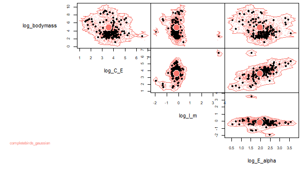

```r
plot(completebirds_gaussian,point.dark.factor=1,color=gg_color_hue(3)[1])
```

Using scaled log-transformed traits:

```r
completebirds_scale_gaussian<-hypervolume_gaussian(data = completecase_species[completecase_species$class=="Aves",16:19],name ="completebirds_scale_gaussian")
```

```r
completebirds_scale_gaussian@Volume
```

```
[1] 7.854457
```

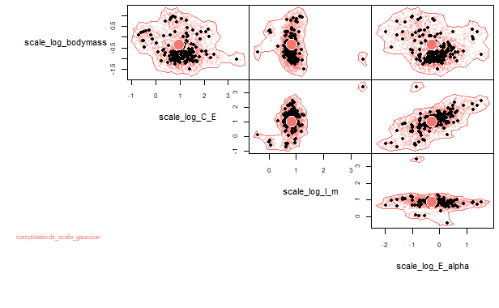

```r
plot(completebirds_scale_gaussian,point.dark.factor=1,color=gg_color_hue(3)[1])
```

The bird hypervolumes show no relationship of body mass with any of the invariant traits, suggesting they truly are invariant for this class.

### Mammal Hypervolumes

Log-transformed traits:

```r
completemammals_gaussian<-hypervolume_gaussian(data = completecase_species[completecase_species$class=="Mammalia",12:15],name = "completemammals_gaussian")
```

```r
completemammals_gaussian@Volume
```

```
[1] 205.559
```

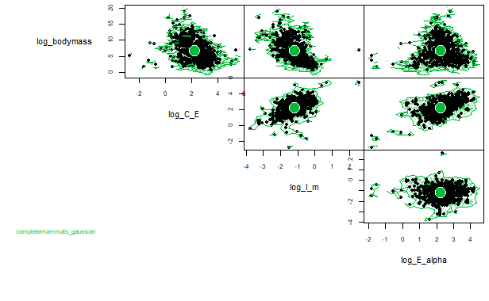

```r
plot(completemammals_gaussian,point.dark.factor=1,color=gg_color_hue(3)[2])
```

Scaled log-transformed traits:

```r
completemammals_scale_gaussian<-hypervolume_gaussian(data = completecase_species[completecase_species$class=="Mammalia",16:19],name ="completemammals_scale_gaussian")
```

```r
completemammals_scale_gaussian@Volume
```

```
[1] 43.17131
```

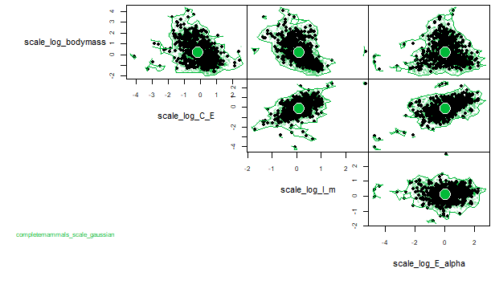

```r
plot(completemammals_scale_gaussian,point.dark.factor=1,color=gg_color_hue(3)[2])
```

For the mammals, there appears to be a weak negative relationship between body mass and $I/m$, implying that this may not be an invariant trait for mammals.

### Reptile Hypervolumes

Log-transformed traits:

```r
completereptiles_gaussian<-hypervolume_gaussian(data = completecase_species[completecase_species$class=="Reptilia",12:15],name = "completereptiles_gaussian")
```

```r
completereptiles_gaussian@Volume
```

```
[1] 645.412
```

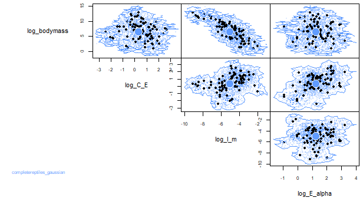

```r
plot(completereptiles_gaussian,point.dark.factor=1,color=gg_color_hue(3)[3])
```

Scaled log-transformed traits:

```r
completereptiles_scale_gaussian<-hypervolume_gaussian(data = completecase_species[completecase_species$class=="Reptilia",16:19],name = "completereptiles_scale_gaussian")
```

```r
completereptiles_scale_gaussian@Volume
```

```
[1] 131.7303
```

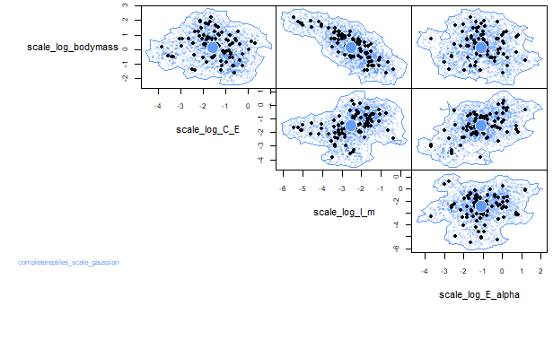

```r
plot(completereptiles_scale_gaussian,point.dark.factor=1,color=gg_color_hue(3)[3])
```

For reptiles, there is a definite negative relationship between mass and $I/m$, so $I/m$ is not an invariant for reptiles.

### All Classes

Finally, I overlaid the hypervolumes for all three classes to visualize differences.

Log-transformed traits:

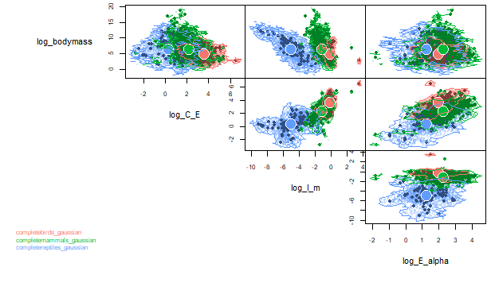

```r
plot(hypervolume_join(completebirds_gaussian,completemammals_gaussian,completereptiles_gaussian),
     colors = c(gg_color_hue(3)[1],gg_color_hue(3)[2],gg_color_hue(3)[3]))
```

Scaled log-transformed traits:

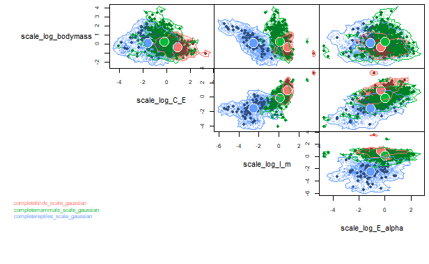

```r
plot(hypervolume_join(completebirds_scale_gaussian,completemammals_scale_gaussian,completereptiles_scale_gaussian),
     colors = c(gg_color_hue(3)[1],gg_color_hue(3)[2],gg_color_hue(3)[3]))
```

There is noticeable separation between the centroids for the three different classes. The bird hypervolume is noticeably smaller than that of the mammals or reptiles, and it often overlaps with the mammal hypervolume quite a bit. The reptile hypervolume is largest and mostly distinct from the other two. Thus it appears like birds have the narrowest range of life history value combinations while reptiles have the largest.